# R Notebook

```r
library(dplyr)
```

```r
library(ggplot2)
library(tidyr)
```

# On aggregate level

We use the following equation:

$$PV_{loan}=\sum_{t=1}^T\frac{\alpha \cdot \max\{0,
Y_0(1+g)^{t-1}-\tau\}}{(1+r)^t}$$

hence the k is calculated with the following assumptions:

$$\Delta \log(P_i)=log(22200)-log\left(\sum_{t=1}^T\frac{\alpha \cdot
\max\{0, Y_i(1+g)^{t-1}-\tau\}}{(1+r)^t}\right)$$

where $Y_i$ is the starting salary in country i.

```r
# Present value of repayments
# (payments stop when loan is repaid)

pv_loan <- function(Y0,
                    L = 9250,        # loan principal (1 year)
                    alpha = 0.09,    # repayment rate
                    tau = 27295,     # threshold
                    g = 0.02,        # wage growth
                    r = 0.03,        # discount rate
                    T = 30){         # years

  balance <- L
  pv <- 0

  for(t in 1:T){

    # income path
    Yt <- Y0 * (1 + g)^(t - 1)

    # repayment rule
    Rt <- alpha * max(0, Yt - tau)

    # cannot repay more than remaining balance
    payment <- min(Rt, balance)

    # discounted payment
    pv <- pv + payment / (1 + r)^t

    # update remaining loan
    balance <- balance - payment

    # stop once repaid
    if(balance <= 0){
      break
    }
  }

  return(pv)
}
```

```r
beta  <- -1.28
Ppost <- 22200

elasticity_from_income <- function(Y0){
  PV <- pv_loan(Y0)

  # avoid log(0) for very low incomes
  PV <- max(PV, 1)

  k  <- log(Ppost) - log(PV)
  eta <- -beta / k

  return(c(PV = PV, k = k, elasticity = eta))
}
```

```r
salary_levels <- c(20000, 26000, 32000, 42000, 32000, 35000, 42000, 50000)

results <- t(sapply(salary_levels, elasticity_from_income))

table_results <- data.frame(
  Starting_Salary = salary_levels,
  PV_Loan = round(results[,1], 2),
  k = round(results[,2], 3),
  Elasticity = round(results[,3], 3)
)

table_results
```

| Starting_Salary | PV_Loan | k | Elasticity |
| --- | --- | --- | --- |
| 20000 | 2366.69 | 2.239 | 0.572 |
| 26000 | 5835.48 | 1.336 | 0.958 |
| 32000 | 7435.25 | 1.094 | 1.170 |
| 42000 | 8301.81 | 0.984 | 1.301 |
| 32000 | 7435.25 | 1.094 | 1.170 |
| 35000 | 7822.44 | 1.043 | 1.227 |
| 42000 | 8301.81 | 0.984 | 1.301 |
| 50000 | 8547.92 | 0.954 | 1.341 |

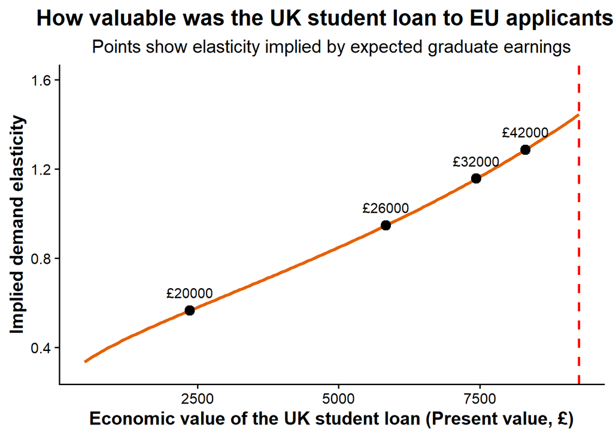

```r
library(ggplot2)

beta  <- -1.265
Ppost <- 22200

PV <- seq(500, 9250, by = 50)
elasticity <- -beta / (log(Ppost) - log(PV))
curve_df <- data.frame(PV, elasticity)

# ---- loan valuation function ----
pv_loan <- function(Y0,
                    L = 9250,
                    alpha = 0.09,
                    tau = 27295,
                    g = 0.02,
                    r = 0.03,
                    T = 30){

  balance <- L
  pv <- 0

  for(t in 1:T){
    Yt <- Y0 * (1 + g)^(t - 1)
    Rt <- alpha * max(0, Yt - tau)
    payment <- min(Rt, balance)
    pv <- pv + payment/(1+r)^t
    balance <- balance - payment
    if(balance <= 0) break
  }

  return(max(pv,1))
}

# only representative income groups (not 10 lines)
salary_levels <- c(20000, 26000, 32000, 42000)

salary_df <- data.frame(
  salary = salary_levels,
  PV = sapply(salary_levels, pv_loan)
)

salary_df$elasticity <- -beta/(log(Ppost)-log(salary_df$PV))

# ---- plot ----
ggplot(curve_df, aes(PV, elasticity)) +

  # main curve
  geom_line(linewidth=1.4, color="#E66100") +

  # benchmark tuition
  geom_vline(xintercept = 9250,
             linetype="dashed",
             color="red",
             linewidth=1) +

  # salary points
  geom_point(data=salary_df,
             aes(PV, elasticity),
             size=3.5,
             color="black") +

  # labels above points
  geom_text(data=salary_df,
            aes(PV, elasticity, label=paste0("£",salary)),
            nudge_y=0.08,
            size=4) +

  labs(
    x="Economic value of the UK student loan (Present value, £)",
    y="Implied demand elasticity",
    title="How valuable was the UK student loan to EU applicants?",
    subtitle="Points show elasticity implied by expected graduate earnings"
  ) +

  coord_cartesian(ylim=c(0.3,1.6)) +

  theme_classic(base_size=15) +
  theme(
    plot.title = element_text(face="bold", hjust=0.5),
    plot.subtitle = element_text(hjust=0.5),
    axis.title = element_text(face="bold")
  )
```

# Country specific present values

```r
library(readxl)
wages<-read_excel("wages.xlsx", sheet="main_df")
```

```r
eur_gbp <- 0.86
wages$wage_gbp <- wages$Wage_EURO * eur_gbp

wages$PV_loan <- sapply(wages$wage_gbp, pv_loan)
Ppost <- 22200

wages$k_i <- log(Ppost) - log(wages$PV_loan)
```

```r
betas_saturated_model <- read_excel("betas_saturated_model.xlsx")
wages<-merge(wages,betas_saturated_model, by="Country" )
```

```r
wages$elasticity_new_TWFE <- as.numeric(wages$Estimate_TWFE) / wages$k_i
wages$elasticity_new_OWFE <- as.numeric(wages$Estimate_OWFE) / wages$k_i
wages$elasticity_new_Pooled <- as.numeric(wages$Estimate_Pooled) / wages$k_i
wages$elasticity_TWFE <- as.numeric(wages$Estimate_TWFE) / 0.86
wages$elasticity_OWFE <- as.numeric(wages$Estimate_OWFE) / 0.86
wages$elasticity_Pooled <- as.numeric(wages$Estimate_Pooled) / 0.86
```

```r
results_country <- wages[, c("Country", "Wage_EURO", "PV_loan", "k_i", "elasticity_new_TWFE","elasticity_new_OWFE","elasticity_new_Pooled", "elasticity_TWFE", "elasticity_OWFE","elasticity_Pooled" )]

results_country
```

| Country | Wage_EURO | PV_loan | k_i | elasticity_new_TWFE | elasticity_new_OWFE | elasticity_new_Pooled | elasticity_TWFE | elasticity_OWFE | elasticity_Pooled |
| --- | --- | --- | --- | --- | --- | --- | --- | --- | --- |
| Austria | 58600 | 8557.614414 | 0.9532708 | -0.7393534 | -0.55095885 | -1.083209483 | -0.8195395 | -0.6107128 | -1.20068837 |
| Belgium | 59632 | 8579.338451 | 0.9507355 | -0.7982525 | -0.60935561 | -0.531850351 | -0.8824733 | -0.6736465 | -0.58796395 |
| Bulgaria | 15387 | 1.000000 | 10.0078476 | -0.2041814 | -0.18623635 | -0.107731757 | -2.3760651 | -2.1672384 | -1.25367791 |
| Croatia | 23446 | 2527.465580 | 2.1728752 | -0.8334643 | -0.75081301 | -1.216781321 | -2.1058302 | -1.8970035 | -3.07431860 |
| Cyprus | 27611 | 5095.437253 | 1.4717468 | -0.7191672 | -0.59714144 | 0.124508509 | -1.2307349 | -1.0219081 | 0.21307558 |
| Czechia | 23998 | 3021.095677 | 1.9944727 | -0.6485278 | -0.55848345 | -0.487700830 | -1.5040360 | -1.2952093 | -1.13105349 |
| Denmark | 71565 | 8724.530547 | 0.9339536 | -1.2878295 | -1.09553833 | -1.799913775 | -1.3985733 | -1.1897465 | -1.95469302 |
| Estonia | 26546 | 4804.713962 | 1.5304948 | -1.0478402 | -0.93049844 | -1.508614099 | -1.8647837 | -1.6559570 | -2.68479767 |
| Finland | 49428 | 8323.749959 | 0.9809794 | -1.9497004 | -1.76662728 | -1.925494014 | -2.2239721 | -2.0151453 | -2.19636047 |
| France | 43790 | 8054.806005 | 1.0138234 | -0.7431028 | -0.56596053 | 1.092060065 | -0.8760174 | -0.6671907 | 1.28739070 |

[output cut: 15 more lines]

# Correlations

```r
library(WDI)
gdp <- WDI(
  country = "all",
  indicator = "NY.GDP.PCAP.PP.KD",
  start = 2022,
  end = 2022
)
wages <- merge(
  wages,
  gdp[, c("country", "NY.GDP.PCAP.PP.KD")],
  by.x = "Country",
  by.y = "country",
  all.x = TRUE
)
names(wages)[which(names(wages) == "NY.GDP.PCAP.PP.KD")]<-"GDP_PPP"
```

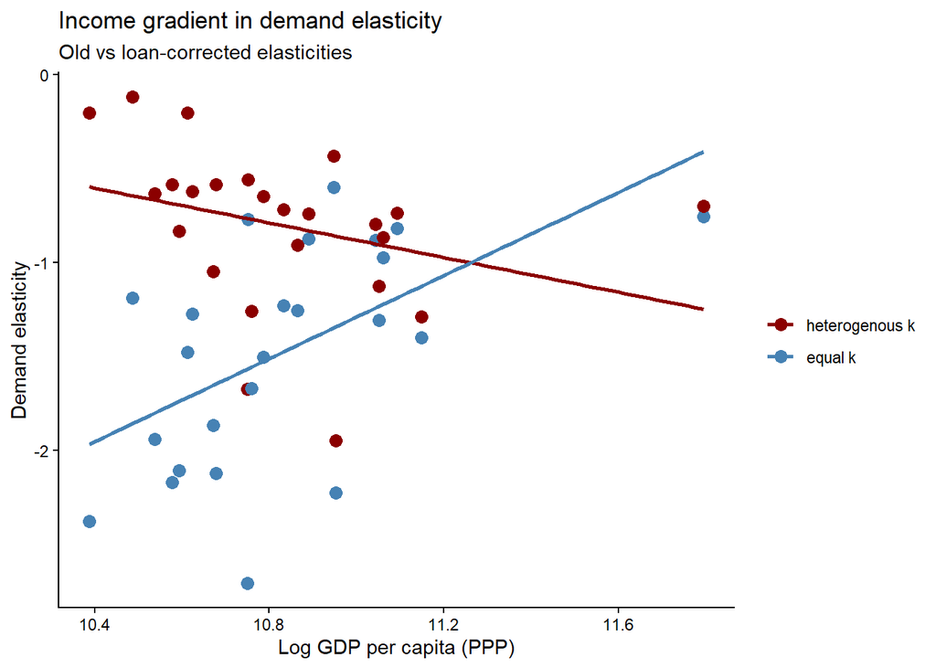

```r
library(dplyr)

df <- wages %>%
  filter(!is.na(GDP_PPP))
df$log_gdp <- log(df$GDP_PPP)


df_long <- df %>%
  pivot_longer(
    cols = c(elasticity_TWFE, elasticity_new_TWFE),
    names_to = "type",
    values_to = "elas"
  )

ggplot(df_long, aes(x = log_gdp, y = elas, color = type)) +
  geom_point(size = 3) +
  geom_smooth(method = "lm", se = FALSE) +
  scale_color_manual(
    values = c("elasticity_TWFE" = "steelblue",
               "elasticity_new_TWFE" = "darkred"),
    labels = c("elasticity_TWFE" = "equal k",
               "elasticity_new_TWFE" = "heterogenous k")
  ) +
  labs(
    x = "Log GDP per capita (PPP)",
    y = "Demand elasticity",
    color = NULL,
    title = "Income gradient in demand elasticity",
    subtitle = "Old vs loan-corrected elasticities"
  ) +
  theme_classic()
```

# Regression comparisons (TWFE vs OWFE vs Pooled)

Consider the following panel data models:

$$Y_{it} = \beta_i D_{it} + \alpha_i + \varepsilon_{it} \quad
\text{(One-way fixed effects)}$$

$$Y_{it} = \beta_i D_{it} + \alpha_i + \gamma_t + \varepsilon_{it} \quad
\text{(Two-way fixed effects)}$$

where $i$ indexes countries and $t$ indexes time. The parameter $\beta_i$ captures the country-specific treatment effect (elasticity), $\alpha_i$ are country fixed effects, and $\gamma_t$ are time fixed effects. The one-way fixed effects estimator removes country means:

$$\tilde{Y}_{it}^{(1)} = Y_{it} - \bar{Y}_i$$

The two-way fixed effects estimator removes both country and time means:

$$\tilde{Y}_{it}^{(2)} = Y_{it} - \bar{Y}_i - \bar{Y}_t + \bar{Y}$$

Subtracting the one-way transformation from the two-way transformation yields:

$$\tilde{Y}_{it}^{(2)} - \tilde{Y}_{it}^{(1)} &= -\bar{Y}_t + \bar{Y}
\\
\Rightarrow \tilde{Y}_{it}^{(2)} &= \tilde{Y}_{it}^{(1)} -
(\bar{Y}_t - \bar{Y})$$

If $\gamma_t$ represents a common time effect across countries, then:

$$\bar{Y}_t - \bar{Y} \approx \gamma_t$$

so that:

$$\tilde{Y}_{it}^{(2)} = \tilde{Y}_{it}^{(1)} - \gamma_t$$

Let $\hat{\beta}_i^{OWFE}$ and $\hat{\beta}_i^{TWFE}$ denote the country-specific elasticities obtained from the one-way and two-way fixed effects models, respectively. Then:

$$\hat{\beta}_i^{TWFE} = \hat{\beta}_i^{OWFE} - c$$

where $c$ is a constant given by the average time effect:

$$c = \frac{1}{T} \sum_{t} \gamma_t$$

This implies a linear relationship between the two estimators:

$$\hat{\beta}_i^{TWFE} = \alpha + 1 \cdot \hat{\beta}_i^{OWFE}, \quad
\text{with } \alpha = -c$$

Thus, the slope is equal to one and the difference between the two estimators is a constant shift.

```r
reg_old <- lm(elasticity_TWFE ~ log_gdp, data = df)

reg_new_TWFE <- lm(elasticity_new_TWFE ~ log_gdp, data = df)

# Now the other two regressions

reg_old_OWFE <- lm(elasticity_OWFE  ~ log_gdp, data = df)
reg_old_Pooled <- lm(elasticity_Pooled ~ log_gdp, data = df)

stargazer::stargazer(reg_old,reg_new_TWFE,reg_old_OWFE,reg_old_Pooled ,  type="text")
```

```
##
## ===================================================================================================
##                                                        Dependent variable:
##                               ---------------------------------------------------------------------
##                               elasticity_TWFE elasticity_new_TWFE elasticity_OWFE elasticity_Pooled
##                                     (1)               (2)               (3)              (4)
## ---------------------------------------------------------------------------------------------------
## log_gdp                          1.105***           -0.461           1.105***           0.076
##                                   (0.361)           (0.299)           (0.361)          (0.987)
##
## Constant                        -13.443***           4.193          -13.234***         -1.874
##                                   (3.916)           (3.239)           (3.916)         (10.690)
##
## ---------------------------------------------------------------------------------------------------
## Observations                        24                24                24               24
## R2                                 0.298             0.098             0.298           0.0003
## Adjusted R2                        0.266             0.057             0.266           -0.045
## Residual Std. Error (df = 22)      0.506             0.419             0.506            1.382
## F Statistic (df = 1; 22)         9.340***            2.380           9.340***           0.006
## ===================================================================================================
## Note:                                                                   *p<0.1; **p<0.05; ***p<0.01
```

#Other interesting correlations

```r
# Packages
library(WDI)
library(dplyr)
library(countrycode)
library(broom)
library(purrr)

# EU countries
eu_iso2 <- c(
  "AT","BE","BG","HR","CY","CZ","DK","EE","FI","FR","DE","GR",
  "HU","IE","IT","LV","LT","LU","MT","NL","PL","PT","RO","SK",
  "SI","ES","SE"
)

# World Bank indicators
indicators <- c(
  gdp_ppp_pc      = "NY.GDP.PCAP.PP.KD",
  gini            = "SI.POV.GINI",
  youth_unemp     = "SL.UEM.1524.ZS",
  educ_spend_gdp  = "SE.XPD.TOTL.GD.ZS",
  tertiary_enroll = "SE.TER.ENRR",
  net_migration   = "SM.POP.NETM"
)

# Download World Bank data
wb <- WDI(
  country = eu_iso2,
  indicator = indicators,
  start = 2022,
  end = 2022
) %>%
  select(iso2c, country, all_of(names(indicators)))

# Add ISO codes to your elasticity data
df_clean <- df %>%
  mutate(iso2c = countrycode(Country, "country.name", "iso2c"))

# Merge elasticities with World Bank data
dat <- df_clean %>%
  left_join(wb, by = "iso2c")
```

```r
library(dplyr)
library(stargazer)
wb_vars <- c(
  "gdp_ppp_pc",
  "gini",
  "youth_unemp",
  "educ_spend_gdp",
  "tertiary_enroll",
  "net_migration"
)

min_n <- 8  # minimum complete cases to include a model

# Build models safely
models_new <- list()
kept_vars  <- c()

for (v in wb_vars) {
  dsub <- dat %>% select(elasticity_new_TWFE, all_of(v)) %>% filter(complete.cases(.))

  # Skip if too few obs or regressor has no variation
  if (nrow(dsub) < min_n) next
  if (sd(dsub[[v]], na.rm = TRUE) == 0) next

  m <- lm(reformulate(v, response = "elasticity_new_TWFE"), data = dsub)

  models_new[[v]] <- m
  kept_vars <- c(kept_vars, v)
}

# Check what got included
print(kept_vars)
```

```
## [1] "gdp_ppp_pc"      "gini"            "youth_unemp"     "educ_spend_gdp"
## [5] "tertiary_enroll" "net_migration"
```

```r
# Stargazer output
stargazer(
  models_new,
  type = "text"
)
```

```
##
## =========================================================================================================================================
##                                                                      Dependent variable:
##                     ---------------------------------------------------------------------------------------------------------------------
##                                                                               v
##                            (1)                (2)                (3)                  (4)                  (5)                (6)
## -----------------------------------------------------------------------------------------------------------------------------------------
## gdp_ppp_pc               -0.00000
##                         (0.00000)
##
## gini                                         0.040
##                                             (0.025)
##
## youth_unemp                                                     0.012
##                                                                (0.013)
##
## educ_spend_gdp                                                                     -0.251***
##                                                                                     (0.077)
##
## tertiary_enroll                                                                                           0.001
##                                                                                                          (0.004)
##
## net_migration                                                                                                               0.00000
##                                                                                                                            (0.00000)
##
## Constant                 -0.576**           -2.097**          -0.996***              0.411               -0.885**          -0.813***
##                          (0.256)            (0.792)            (0.231)              (0.381)              (0.317)            (0.105)
##
## -----------------------------------------------------------------------------------------------------------------------------------------
## Observations                24                 23                 24                   23                   24                 24
## R2                        0.039              0.110              0.036                0.334                0.003              0.002
## Adjusted R2               -0.005             0.068              -0.008               0.302                -0.042             -0.044
## Residual Std. Error  0.432 (df = 22)    0.407 (df = 21)    0.433 (df = 22)      0.368 (df = 21)      0.440 (df = 22)    0.440 (df = 22)
## F Statistic         0.890 (df = 1; 22) 2.595 (df = 1; 21) 0.820 (df = 1; 22) 10.519*** (df = 1; 21) 0.073 (df = 1; 22) 0.040 (df = 1; 22)
## =========================================================================================================================================
## Note:                                                                                                         *p<0.1; **p<0.05; ***p<0.01
```